# Music Recommendation - Hybrid Recommender System using Factorization Machines, Content Based Recommenders and SVD++

Columbia University IEOR 4571 - Personalization Theory and Applications - Final Report Part II

Gaurav Singh, Carolyn Silverman, Cindy Wu, Maura Fitzerald

15 December 2017

```r
library(knitr)
load('FM/FM.RData')
source('Requirements.R')
read_chunk('FM/factorization_machines.R')
read_chunk('Evaluation/Evaluation.R')
read_chunk('content_based/libraries.R')
read_chunk('content_based/read_filter.R')
read_chunk('content_based/feature_generation.R')
read_chunk('content_based/collaborative_filter.R')
read_chunk('content_based/knn.R')
options(tibble.print_max = 5, tibble.print_min = 5)
```

## Introduction and Objectives

Not many years ago, it was inconceivable that the same person would listen to the Beatles, Vivaldi, and Lady Gaga on their morning commute. But, the glory days of Radio DJs have passed, and musical gatekeepers have been replaced with personalizing algorithms and unlimited streaming services.

While the public’s now listening to all kinds of music, algorithms still struggle in key areas. Without enough historical data, how would an algorithm know if listeners will like a new song or a new artist? And, how would it know what songs to recommend brand new users?

In this project, we aim to predict the chances of a user listening to a song repetitively after the first observable listening event within a time window was triggered. If there are recurring listening event(s) triggered within a month after the user’s very first observable listening event, its target is marked 1, and 0 otherwise.  
Our dataset come from a Kaggle competition, where KKBOX provides a training data set consisting of information of the first observable listening event for each unique user-song pair within a specific time duration. Metadata of each unique user and song pair is also provided.

The train and the test data are selected from users listening history in a given time period. The train and test sets are split based on time, and the split of public/private are based on unique user/song pairs.

## Music Recommendation Rationale

Automatic music recommendation has become an increasingly relevant problem in recent years, since a lot of music is now sold and consumed digitally. In recent years, the music industry has shifted more and more towards digital distribution through online music stores and streaming services such as iTunes, Spotify, Grooveshark and Google Play.

## Dataset and Exploration

```r
library(tidyverse)
library(data.table)
library(Hmisc)
library(class)
library(recommenderlab)
library(dplyr)
```

The original dataset contains 7,377,418 observations, where each observation corresponds to the first observable listening event for each unique user-song pair. In order to train our models, we filter the data by choosing songs with at least 1000 occurrences and users with at least 500 occurrences. We then train on 75% of the filtered dataset and test on the other 25%. This results in a training set of 869,783 observations and a testing set of 289,928 observations.

```r
options(tibble.print_max = 5, tibble.print_min = 5)
setwd("~/Desktop/drive/dsi/fall-17/personalization/Part II")
rm(list= ls())
train <- as.tibble(fread('data/train.csv'))
songs <- as.tibble(fread('data/songs.csv'))
song_extra_info <- as.tibble(fread('data/song_extra_info.csv'))

ratings <- as.data.table(train[c('msno', 'song_id', 'target')])

filter_song_data <- as.data.frame(table(ratings$song_id))
filter_user_data <- as.data.frame(table(ratings$msno))

names(filter_song_data) <- c('song_id', 'count')
names(filter_user_data) <- c('msno', 'count')
ratings$song_count <- filter_song_data$count[match(ratings$song_id, filter_song_data$song_id)]
ratings$user_count <- filter_user_data$count[match(ratings$msno, filter_user_data$msno)]

sc = 1000
uc = 500
filter_data <- subset(ratings, ratings$song_count>= sc & ratings$user_count >=uc)
nrow(filter_data)/nrow(ratings)
paste('Users:', length(unique(filter_data$msno)))
paste('Songs:', length(unique(filter_data$song_id)))

user_key <- as.data.frame(cbind(unique(filter_data$msno),c(1:length(unique(filter_data$msno)))))
names(user_key) <- c('user_code', 'msno')
song_key <- as.data.frame(cbind(unique(filter_data$song_id), c(1:length(unique(filter_data$song_id)))))
names(song_key) <- c('song_code', 'song_id')
filter_data$msno <- user_key$msno[match(filter_data$msno,user_key$user_code)]
filter_data$song_id <- song_key$song_id[match(filter_data$song_id, song_key$song_code)]


set.seed(666)
train_prop = 0.75
train_test_split <- function(ratings, train_proportion = 0.8){
  sample_size <- floor(train_proportion*nrow(ratings))
  train_ind <- sample(seq_len(nrow(ratings)), size = sample_size)
  train_data <- ratings[train_ind,]
  test_data <- ratings[-train_ind,]
  split_data <- list('train_data' = train_data, 'test_data' = test_data)
  return(split_data)
}
split_data <- train_test_split(filter_data,0.75)
training_data <- split_data$train_data
testing_data <- split_data$test_data
songs$song_id <- song_key$song_id[match(songs$song_id, song_key$song_code)]
songs <- subset(songs, songs$song_id %in% filter_data$song_id)
song_extra_info$song_id <- song_key$song_id[match(song_extra_info$song_id, song_key$song_code)]
song_extra_info <- subset(song_extra_info, song_extra_info$song_id %in% filter_data$song_id)

training_data <- as.tibble(training_data)
```

### Training Data

Let’s start by examining how each variable in the training_data affects the target. We base our exploratory data analysis off of the following kernel: https://www.kaggle.com/adiamaan/eda-and-feature-engineering

| msno | song_id | target | song_count | user_count |
| --- | --- | --- | --- | --- |
| 1519 | 75 | 0 | 4062 | 581 |
| 1436 | 345 | 1 | 1405 | 1624 |
| 1488 | 200 | 1 | 1773 | 620 |
| 1746 | 730 | 0 | 1430 | 1483 |
| 4076 | 649 | 1 | 1494 | 592 |
| 4445 | 1008 | 0 | 1170 | 710 |
| 888 | 994 | 1 | 3530 | 759 |
| 3406 | 776 | 0 | 1166 | 656 |
| 1459 | 577 | 1 | 1606 | 656 |
| 3108 | 52 | 1 | 13079 | 1589 |

[output cut: 9990 more lines]

Defining useful functions:

```r
## ggplot setting for readable labels
readable_labs <- theme(axis.text=element_text(size=12),
                     axis.title=element_text(size=14),
                     plot.title = element_text(hjust = 0.5))

# Function to dislpay count of each category of the column and plot how it affects target
target_vs_column <-function(df, col_name, x , y, title){
    temp_df <- df %>%
            group_by_(col_name) %>%
            summarize(count = n(), mean_target = mean(target)) %>%
            arrange(desc(mean_target))

    df_plot <- temp_df %>%
              ggplot(aes_string(col_name, "mean_target")) +
              geom_col(aes(fill=count)) +
              scale_fill_gradient(low='turquoise', high = 'violet')+
              coord_flip() +
              labs(x = x,
                   y = y,
                   title= title) +
              readable_labs
    print(df_plot)
    return (temp_df)
}

# Function to group songs and user by count and check it agains mean_target
target_vs_colcount <- function(df, col_name, x, y, title){
    df %>%
      group_by_(col_name) %>%
      summarize(count = n(), mean_target = mean(target)) %>%
      group_by(count) %>%
      summarize(new_count = n(), avg_target = mean(mean_target)) %>%
      rename(no_of_items = new_count, occurence = count) %>%
      arrange(desc(avg_target)) %>%
      ggplot(aes(occurence, avg_target)) +
        geom_line(color='turquoise') +
        geom_smooth(color='turquoise') +
        labs(x = x,
             y = y,
             title= title) +
        readable_labs
}
```

#### Song count and User count vs target

##### Song count vs Target

Songs are grouped together and their count is checked against the target variable. The plot below shows the relationship between discoverability and mean target value. It is clear from the plot that the more a song occurs, the more it is discoverable by the user.

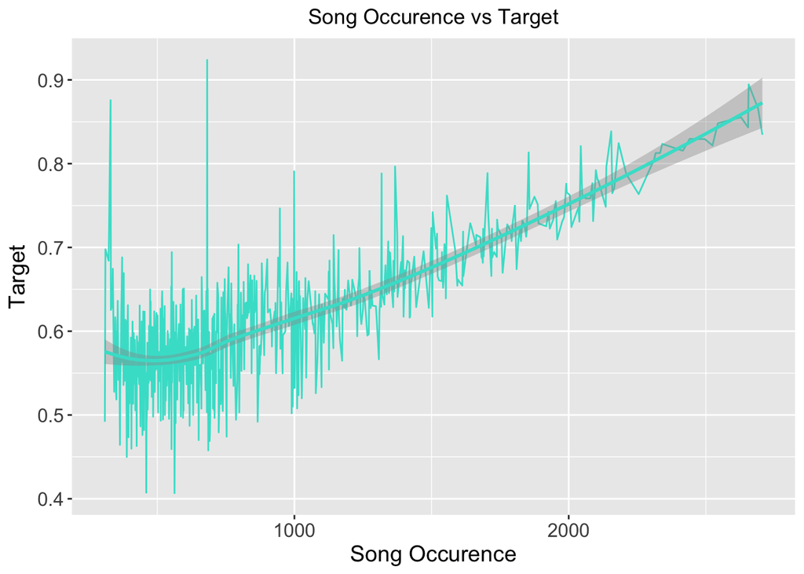

```r
target_vs_colcount(training_data, "song_id", "Song Occurence", "Target", "Song Occurence vs Target")
```

##### User count vs Target

There is also a trend between how frequent of a listener the user is and the likelihood that the will listen to a song repetitively.

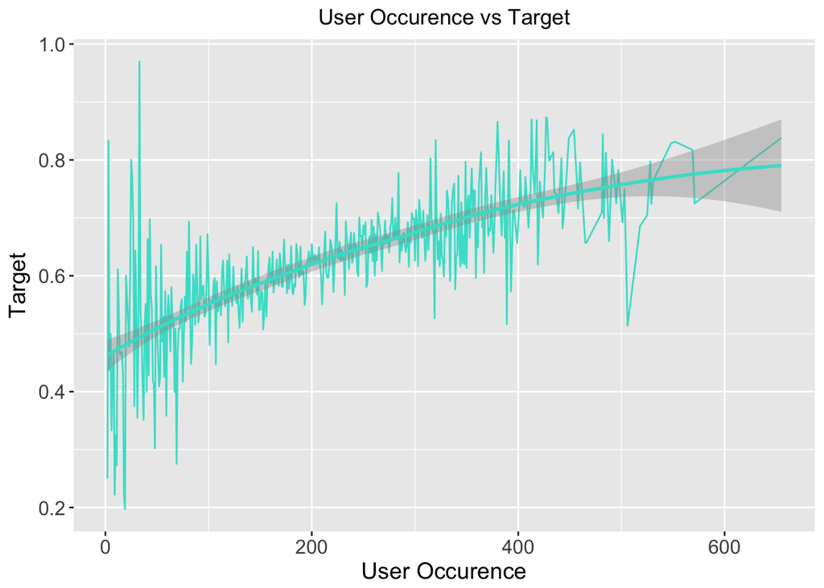

```r
target_vs_colcount(training_data, "msno", "User Occurence", "Target", "User Occurence vs Target")
```

#### Target is unbalanced

Finally, we note that the target variable in our filtered dataset is not balanced. About 63% of the observations in the training data have a target value of one.

```r
training_data %>%
  group_by(target) %>%
  count
```

| target | n |
| --- | --- |
| 0 | 319768 |
| 1 | 550015 |

### Members

Let’s move on to the Members metadata

| msno | city | bd | gender | registered_via | registration_init_time | expiration_date |
| --- | --- | --- | --- | --- | --- | --- |
| 490 | 1 | 0 |  | 7 | 20110820 | 20170920 |
| 2083 | 18 | 0 |  | 9 | 20160128 | 20170914 |
| 2993 | 15 | 22 | male | 4 | 20151029 | 20171006 |
| 182 | 4 | 0 |  | 9 | 20150613 | 20170917 |
| 591 | 13 | 23 | female | 9 | 20130518 | 20171202 |
| 3690 | 15 | 37 | male | 3 | 20120725 | 20171005 |
| 1325 | 5 | 51 | female | 3 | 20150916 | 20170923 |
| 2046 | 15 | 24 | male | 3 | 20130407 | 20171021 |
| 203 | 15 | 26 | male | 9 | 20111107 | 20180304 |
| 3132 | 1 | 0 |  | 3 | 20140320 | 20170925 |

[output cut: 4547 more lines]

In the members dataframe, city, bd, gender, registered via are categorical vairables and registration init and expiration date are dates. We choose not to use registered via or the date features in our models, so we will not explore these variables here.

Again we define some useful functions for exploration to help us determine how each of these variables affects the target:

```r
members_colgroup <- function(df,col_name, x, y, title, xmin, xmax, ymin, ymax){

    temp_df <- df %>%
                  group_by_(col_name) %>%
                  count() %>%
                  arrange(desc(n))

    df_plot <- temp_df %>%
                    ggplot(aes_string(col_name, "n")) +
                    geom_col(fill='goldenrod2') +
                    labs(x = x,
                         y = y,
                         title = title) +
                    xlim(xmin, xmax) +
                    ylim(ymin, ymax) +
                    readable_labs

    print(df_plot)
    return(temp_df)

}
```

#### Distribution of city, bd(age), gender

##### Age

There seem to be some outliers in the age field, so we will have to clean these before we build our models.  
Sorted bd (age) vs Frequency is shown in the tibble as well as the graph. There are 1578 records with 0 as age. This could be either outliers or missing values. We plot in the age range 1-100 to show the real distribution.

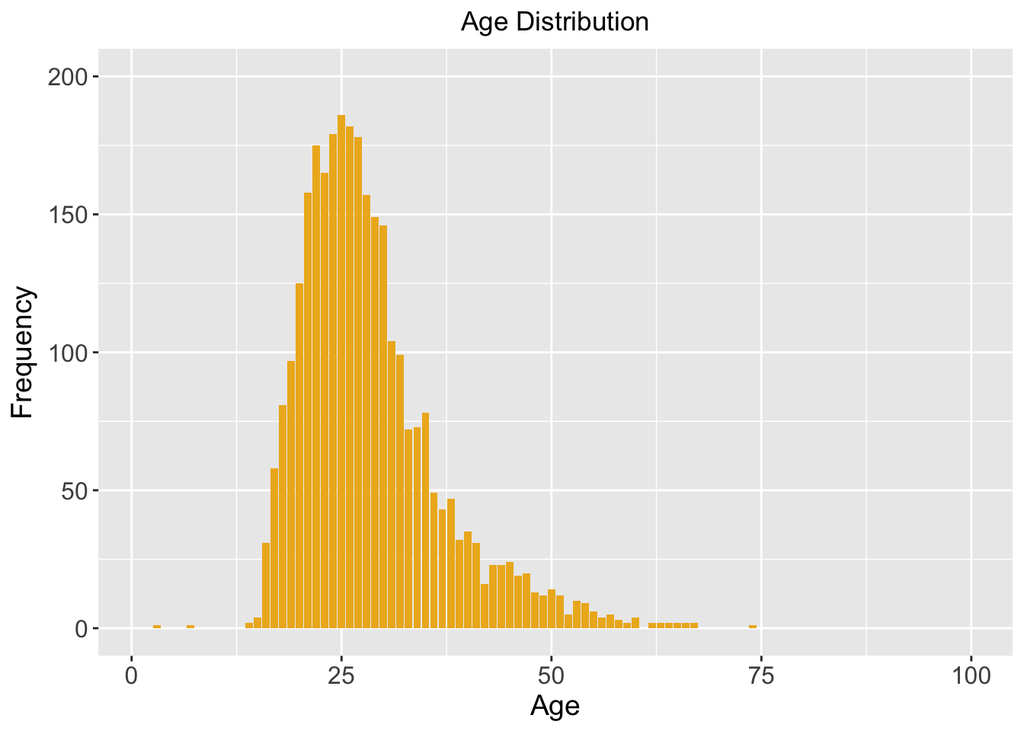

| bd | n |
| --- | --- |
| 0 | 1578 |
| 25 | 186 |
| 26 | 182 |
| 24 | 179 |
| 27 | 178 |
| 22 | 175 |
| 23 | 165 |
| 21 | 158 |
| 28 | 157 |
| 29 | 149 |

[output cut: 51 more lines]

```r
members_colgroup(members, "bd", "Age", "Frequency", "Age Distribution", 1, 100, 0, 200)
```

##### City

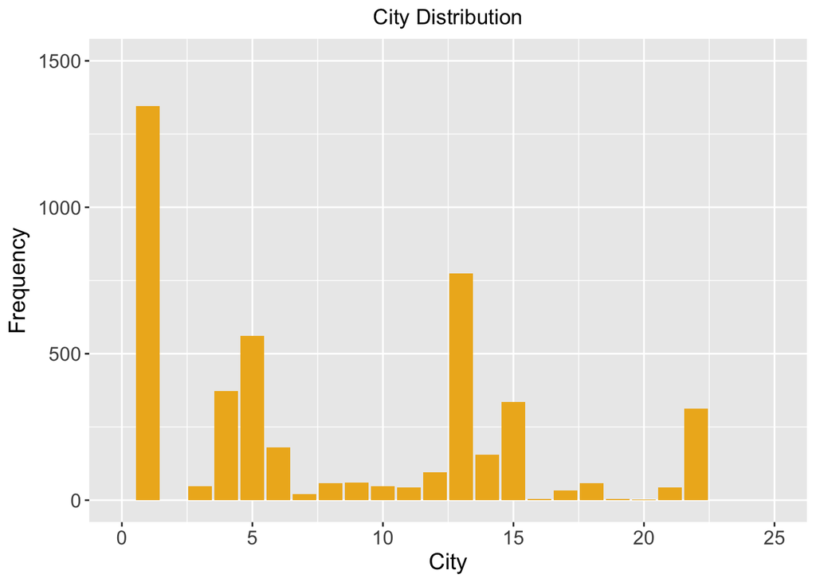

| city | n |
| --- | --- |
| 1 | 1346 |
| 13 | 774 |
| 5 | 560 |
| 4 | 372 |
| 15 | 335 |
| 22 | 312 |
| 6 | 181 |
| 14 | 156 |
| 12 | 95 |
| 9 | 60 |

[output cut: 11 more lines]

```r
members_colgroup(members, "city", "City", "Frequency", "City Distribution", 0, 25, 0, 1500)
```

##### Gender

Male and female are almost equal. We have a lot of missing values, as well.

```r
members %>%
  group_by(gender) %>%
  count
```

| gender | n |
| --- | --- |
|  | 1593 |
| female | 1411 |
| male | 1553 |

### Songs

Finally, let’s examine the available song metadata. These features will be useful for both our content-based recommender and factorization machine model.

```r
songs
```

| song_id | song_length | genre_ids | artist_name | composer | lyricist | language |
| --- | --- | --- | --- | --- | --- | --- |
| 244 | 197328 | 444 | BLACKPINK | TEDDY\| FUTURE BOUNCE\| Bekuh BOOM | TEDDY | 31 |
| 838 | 226742 | 465 | 五月天 (Mayday) | 阿信 | 阿信 | 3 |
| 889 | 220577 | 458 | 英皇團員 | Panot Khunprasert / Prakarn Raiva | 崔恕 | 3 |
| 7 | 288391 | 458 | 陳奕迅 (Eason Chan) | Jun Jie Lin |  | 3 |
| 650 | 256313 | 458 | 周杰倫 (Jay Chou) | 周杰倫 | 方文山 | 3 |
| 497 | 244636 | 458 | 王力宏 (Leehom Wang) | Leehom Wang | Leehom Wang | 3 |
| 118 | 204428 | 921 | LYn | Jay Kim\| Ji Hyang Kim\| Melodesign |  | 31 |
| 575 | 283898 |  | 曾沛慈 (Pets Tseng) | 鴉片丹 | 黃婷 | 3 |
| 805 | 250357 | 465 | 陳勢安 (Andrew Tan) | 戴佩妮 | 戴佩妮 | 3 |
| 284 | 250125 | 458 | 吳建豪 (Vanness Wu) | Terry Lee\| URU |  | 3 |

[output cut: 1063 more lines]

#### Top Items

Let’s see top 100 frequent items in each category,

```r
top_100 <- function(df, col_name)
{
  temp_df <- df %>%
    group_by_(col_name) %>%
    count %>%
    arrange(desc(n)) %>%
    print

  return(temp_df)
}
```

##### Top 100 Artists

```r
artist_count <- top_100(songs, "artist_name")
```

```
## # A tibble: 363 x 2
## # Groups:   artist_name [363]
##         artist_name     n
##               <chr> <int>
## 1 周杰倫 (Jay Chou)    54
## 2   Various Artists    47
## 3   五月天 (Mayday)    40
## 4     田馥甄 (Hebe)    26
## 5   林俊傑 (JJ Lin)    23
## # ... with 358 more rows
```

##### Top 100 Lyricist

```r
lyricist_count <- top_100(songs, "lyricist")
```

```
## # A tibble: 458 x 2
## # Groups:   lyricist [458]
##   lyricist     n
##      <chr> <int>
## 1            303
## 2     阿信    36
## 3   方文山    29
## 4   姚若龍    18
## 5   周杰倫    17
## # ... with 453 more rows
```

##### Top 100 composer

```r
composer_count <- top_100(songs, "composer")
```

```
## # A tibble: 629 x 2
## # Groups:   composer [629]
##   composer     n
##      <chr> <int>
## 1            109
## 2   周杰倫    55
## 3     阿信    20
## 4   林俊傑    17
## 5   陳皓宇    16
## # ... with 624 more rows
```

##### Top 100 Language

```r
language_count <- top_100(songs, "language")
```

```
## # A tibble: 7 x 2
## # Groups:   language [7]
##   language     n
##      <dbl> <int>
## 1        3   719
## 2       52   199
## 3       31   122
## 4       10    13
## 5       17     9
## # ... with 2 more rows
```

21 songs have same artist and lyricist name.  
402 songs have same lyricist and composer name.  
27 songs have same artist and composer name.  
21songs have same artist and lyricist name.

##### Top Genre’s

```r
genre_count <- songs %>%
                  separate(genre_ids, c("one", "two", "three", "four", "five", "six",
                                        "seven", "eight"), extra="merge") %>%
                  select(one:eight)%>%
                  gather(one:eight, key="nth_id", value="genre_ids", na.rm=TRUE) %>%
                  group_by(genre_ids) %>%
                  count %>%
                  arrange(desc(n)) %>%
                  print()
```

```
## # A tibble: 19 x 2
## # Groups:   genre_ids [19]
##   genre_ids     n
##       <chr> <int>
## 1       465   531
## 2       458   289
## 3       921    69
## 4       444    56
## 5      1609    52
## # ... with 14 more rows
```

#### Distribution of song length

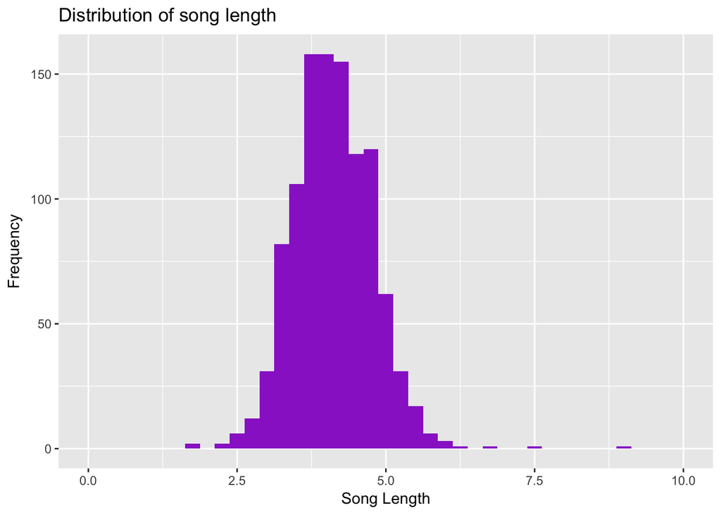

```r
songs %>%
  mutate(song_length = song_length/6e4) %>%
  ggplot(aes(song_length)) +
  geom_histogram(binwidth = 0.25, fill='darkorchid3') +
  labs(x='Song Length', y = 'Frequency', title = 'Distribution of song length') +
  xlim(0, 10)
```

## Collaborative Filter

We build item based and user based collaborative filter model by using the recommenderlab package to take it as a baseline for the future models. Important parameters for the model are:  
* Similarity Measure: Jaccard, as the ratings are binary * Number of neighbors: 30

### Item Based CF

```r
user_item_rating <- dcast(training_data, formula = msno~song_id, value.var = 'target')
training_sparse <- as(as.matrix(user_item_rating[-1]), 'realRatingMatrix')

ibcf <- Recommender(data = training_sparse, method = "IBCF", parameter = list(method = "Jaccard"))
predicted_ratings <- predict(ibcf, training_sparse, type = 'ratings')
predicted_ratings <- as(predicted_ratings, 'matrix')
predicted_ratings <- as.data.frame(predicted_ratings)
predicted_ratings$msno <- user_item_rating$msno
predicted_ratings_melt <- melt(predicted_ratings, id.vars = 'msno', variable.name = 'song_id')
results_ibcf <- merge(testing_data, predicted_ratings_melt, by = c('msno', 'song_id'))
results_ibcf$predicted_class <- 1
results_ibcf$predicted_class[results_ibcf$value < 0.5] <- 0
```

### User Based CF

```r
ubcf <- Recommender(data = training_sparse, method = "UBCF", parameter = list(method = "Jaccard"))
predicted_ratings <- predict(ubcf, training_sparse, type = 'ratings')
predicted_ratings <- as(predicted_ratings, 'matrix')
predicted_ratings <- as.data.frame(predicted_ratings)
predicted_ratings$msno <- user_item_rating$msno
predicted_ratings_melt <- melt(predicted_ratings, id.vars = 'msno', variable.name = 'song_id')
results_ubcf <- merge(testing_data, predicted_ratings_melt, by = c('msno', 'song_id'))
results_ubcf$predicted_class <- 1
results_ubcf$predicted_class[results_ubcf$value < 0.5] <- 0
results_ubcf$random_class <- 1
```

### Baseline Accuracy Measures

```r
conf_matrix_cf_ibcf <- table(results_ibcf$target, results_ibcf$predicted_class)
ibcf_accuracy <- (conf_matrix_cf_ibcf[1,1]+conf_matrix_cf_ibcf[2,2])/sum(conf_matrix_cf_ibcf)
conf_matrix_cf_ubcf <- table(results_ubcf$target, results_ubcf$predicted_class)
ubcf_accuracy <- (conf_matrix_cf_ubcf[1,1]+conf_matrix_cf_ubcf[2,2])/sum(conf_matrix_cf_ubcf)
conf_matrix_rand <- table(results_ubcf$target, results_ubcf$random_class)
rand_accuracy <- (conf_matrix_rand[2,1])/sum(conf_matrix_rand)

cf_accuracy <- as.data.frame(cbind(c('item_based', 'user_based', 'random'), c(ibcf_accuracy, ubcf_accuracy, rand_accuracy)))
names(cf_accuracy) <- c('model', 'accuracy')
cf_accuracy$accuracy_r <- round(as.numeric(as.character(cf_accuracy$accuracy)), 4)
```

```r
paste('Random Prediction Accuracy is: ', round(ubcf_accuracy,4))
```

[output not shown]

```r
paste('Item-Based Collaborative Filter Accuracy is: ', round(ibcf_accuracy,4))
```

```
## [1] "Item-Based Collaborative Filter Accuracy is:  0.7073"
```

```r
print('IBCF Confusion Matrix')
```

```
## [1] "IBCF Confusion Matrix"
```

```r
conf_matrix_cf_ibcf
```

```
##
##          0      1
##   0  40460  65997
##   1  18875 164592
```

```r
paste('User-Based Collaborative Filter Accuracy is: ', round(ubcf_accuracy,4))
```

```
## [1] "User-Based Collaborative Filter Accuracy is:  0.6743"
```

```r
print('UBCF Confusion Matrix')
```

```
## [1] "UBCF Confusion Matrix"
```

```r
conf_matrix_cf_ubcf
```

```
##
##          0      1
##   0  30538  75919
##   1  18514 164953
```

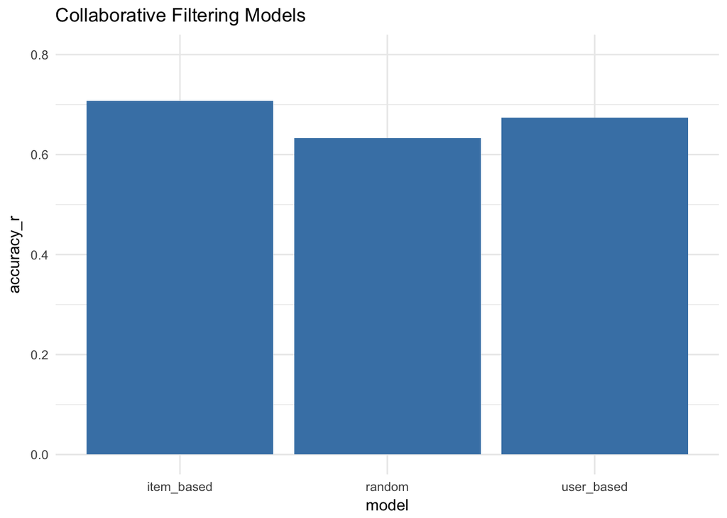

```r
p <- ggplot(data=cf_accuracy, aes(x=model, y=accuracy_r)) +
  geom_bar(stat="identity", fill="steelblue")+ ylim(0,0.8) +
  ggtitle('Collaborative Filtering Models') +
  theme_minimal()
p
```

- We can see that item-based and user-based collaborative filters are better performing than recommending every song to the user.

## Factorization Machines

### Model Summary:

We first explore factorization machines. At their core, factorization machines allow us to model feature-rich datasets by including higher order interactions weighted by the inner product of latent vectors. As a result, we can estimate reliable parameters even in highly sparse data! Factorization machines consist of the following parameters that must be learned (where n is the number of features in the dataset and k is the dimenstionality of the latent features):

- $w_0$ – the global bias term
- $\mathbf{w}$ – a vector of weights for each of the n input variables
- $V$ – an $n \times k$ matrix, where the inner product of the $i^{th}$ and $j^{th}$ row of $V$ is the weight of the interaction between the $i^{th}$ and $j^{th}$ input variable.

The model is written as:
$$\hat{y}(\mathbf{x}) := w_0 + \sum_{j=1}^pw_jx_j + \sum_{j=1}^p \sum_{j'=j+1}^p x_jx_{j'} \sum_{f=1}^kv_{j,f}v_{j'\,f}$$

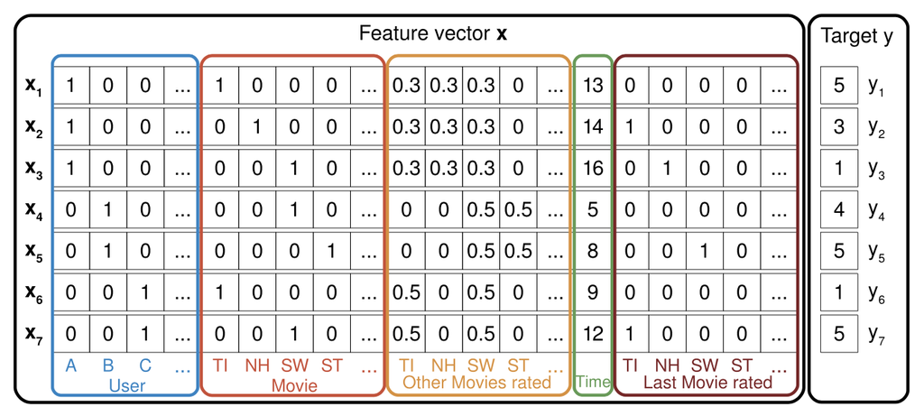

The image above (from Rendle [2010]) shows the format the data must be in to train a factorization machine model. Each feature vector $\mathbf{x}$ is used to predict each target value *$y$*. In our dataset, we one hot encode songs (song_id) and members (msno). Additionally, we include the following features from the metadata to improve accuracy of predictions:

Song metadata:

- Language
- Artist name
- Genre (first listed if multiple)
- Number of genres
- Song length

Member metadata:

- City
- Gender
- Birthday (age)

Additional features:

- Source system tab
- Source screen name
- Source type

We begin by merging the training dataset with the song and member metadata and doing some data cleaning and feature engineering:

```r
all <- data.table(rbind(training_data, testing_data))

# clean song genre
songs %<>%
  separate(genre_ids, c("one", "two", "three", "four", "five", "six", "seven", "eight"),
           extra="merge") %>%
  replace_na(list(one = 0, two = 0, three = 0, four = 0,
                  five = 0, six = 0, seven = 0, eight = 0)) %>%
  mutate(no_of_genre = (if_else(one == 0, 0, 1) + if_else(two == 0, 0, 1) +
                          if_else(three == 0, 0, 1) + if_else(four == 0, 0, 1) +
                          if_else(five == 0, 0, 1) + if_else(six == 0, 0, 1) +
                          if_else(seven == 0, 0, 1) + if_else(eight == 0, 0, 1))) %>%
  select(song_id, song_length, language, artist_name, no_of_genre, one)

#add metadata
merged_all <- all %>%
  left_join(songs, by = "song_id") %>%
  left_join(members, by = "msno") %>%
  left_join(train, by = c("msno", "song_id", "target"))

#drop variables from the merged data
merged_all %<>%
  select(-song_count, -user_count, -registered_via, -registration_init_time, -expiration_date)

#clean data: categorical variables must be coded as factors to train the model
merged_all <- within(merged_all, {
  bd[bd < 14 | bd > 100] <- median(bd) #set age outliers to median
  logbd <- log(bd)
  log_song_length <- log10(song_length)
  one <- factor(one)
  msno <- factor(msno)
  song_id <- factor(song_id)
  artist_name <- factor(artist_name)
  language <- factor(language)
  city <- factor(city)
  gender <- factor(gender)
  source_system_tab <- factor(source_system_tab)
  source_screen_name <- factor(source_screen_name)
  source_type <- factor(source_type)
})

merged_training <- merged_all[1:nrow(training_data),]
merged_testing <- merged_all[-c(1:nrow(training_data)),]
```

The dataset is large, so for the sake of efficiency, we use the R library libFMexe which is an interface to the C++ libFM library by Steffen Rendle. This allows us to run many models and tune k, the hyperparameter for the number of latent dimensions.

While we explored factorization machines with several different learning methods (e.g. ALS and SGD), the model we present here is a second order factorization machine using Markov chain Monte Carlo. Stochastic gradient descent and alternating least squares require additional parameter tuning to determine the optimal learning rate (SGD) and regularization terms (SGD and ALS), which is simply not feasible given the size of the data set and our compute resources. Furthermore, from preliminary models, MCMC appeared to outperform both SGD and ALS, so the choice of MCMC as the learning method for the model is obvious to maximize prediction accuracy.

### Tuning Hyperparameters

#### Choosing k:

We use 3-fold cross validation with 100 iterations of MCMC to determine the optimal number of latent dimensions k. For each fold, the model outputs a vector of probabilities equal to the size of the held out data. This vector is converted to a vector of binary values based on a probability threshold of 0.5. The accuracy is then taken to be the number of target values that the model correctly predicted divided by the total number of target values in the held out data. The error rate is (1 – accuracy).

```r
k.vec <- seq(0, 30, by = 5)
cv_k <- cv_libFM(merged_training, target ~ song_id + language + artist_name +
                   one + no_of_genre + msno + city + gender + logbd + log_song_length +
                   source_system_tab + source_screen_name + source_type,
                 task = "c", dims = k.vec, iter = 100, folds = 3,
                 cv_verbosity = 1, verbosity = 1, method = "mcmc")
```

```r
plot_param_cv <- function(k, m, err.bar.width = .1){
  # Plot Parameter Tuning CV Results
  ## input:
  # k: vector of values to test for the hyperparamter
  # m: an n x k matrix of accuracy rates (n = # of folds)
  ## returns list of:
  # data frame of parameter values, mean error rate, and standard error
  # ggplot of the error rate vs. value of the hyperparameter

  err <- 1 - m
  mean <- apply(err, 2, mean)
  se <- apply(err, 2, function(x) sd(x)/sqrt(length(x)))
  df <- data.frame(cbind(k, mean, se))

  p <- ggplot(df, aes(x=k, y=mean)) +
    geom_errorbar(aes(ymin=mean-se, ymax=mean+se),
                  width = err.bar.width, color='blue' ) +
    geom_line(color='blue') +
    ylab("Error Rate") +
    theme(plot.title = element_text(hjust = 0.5))

  return(list(df, p))
}
#use the fm_k_cv data frame in the FM.RData file which contains the console output of cv_libFM
cv_k_results <- plot_param_cv(k.vec, fm_k_cv, err.bar.width = .3)
as.tibble(cv_k_results[[1]])
```

| k | mean | se |
| --- | --- | --- |
| 0 | 0.3025903 | 0.0001734833 |
| 5 | 0.2748217 | 0.0008582219 |
| 10 | 0.2699660 | 0.0002283243 |
| 15 | 0.2686377 | 0.0004871209 |
| 20 | 0.2670627 | 0.0004737159 |
| 25 | 0.2658290 | 0.0001407918 |
| 30 | 0.2658793 | 0.0002708150 |

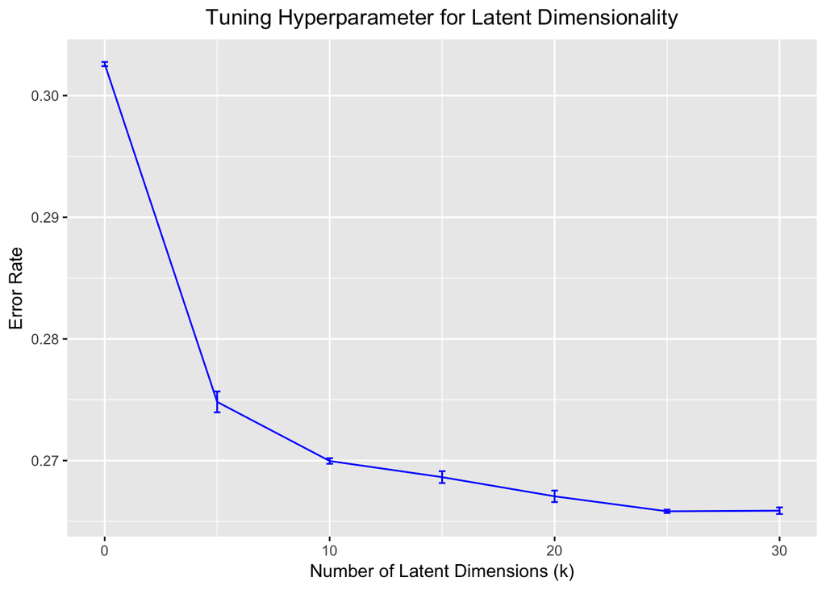

```r
cv_k_results[[2]] + xlab('Number of Latent Dimensions (k)') +
  ggtitle('Tuning Hyperparameter for Latent Dimensionality')
```

```r
k <- k.vec[which.min(cv_k_results[[1]]$mean)]
k
```

```
## [1] 25
```

#### Choosing initialization standard deviation

Next, we use cross-validation to determine the optimal standard deviation initialization. This parameter corresponds to the standard deviation of the normal distribution that is used for initializing the parameters $V$. It is important that we choose a good value for this parameter so that the error rate converges quickly. Again, we use 3-fold cross validation with 100 iterations of MCMC to tune this parameter.

```r
sd.vec <- c(.01, .05, .1, .15, .2)
cv_sd <- cv_libFM(merged_training, target ~ song_id + language + artist_name +
                   one + no_of_genre + msno + city + gender + logbd + log_song_length +
                   source_system_tab + source_screen_name + source_type,
                 task = "c", dim = k, init_stdevs = sd.vec, iter = 100, folds = 3,
                 cv_verbosity = 1, verbosity = 1, method = "mcmc")
```

```r
#use the fm_sd_cv data frame in the FM.RData file which contains the console output of cv_libFM
cv_sd_results <- plot_param_cv(sd.vec, fm_sd_cv, err.bar.width = .003)
cv_sd_results[[1]]
```

| k | mean | se |
| --- | --- | --- |
| 0.01 | 0.2721220 | 0.0009194353 |
| 0.05 | 0.2692273 | 0.0009477553 |
| 0.10 | 0.2669080 | 0.0003292329 |
| 0.15 | 0.2691973 | 0.0015349767 |
| 0.20 | 0.2764280 | 0.0015390313 |

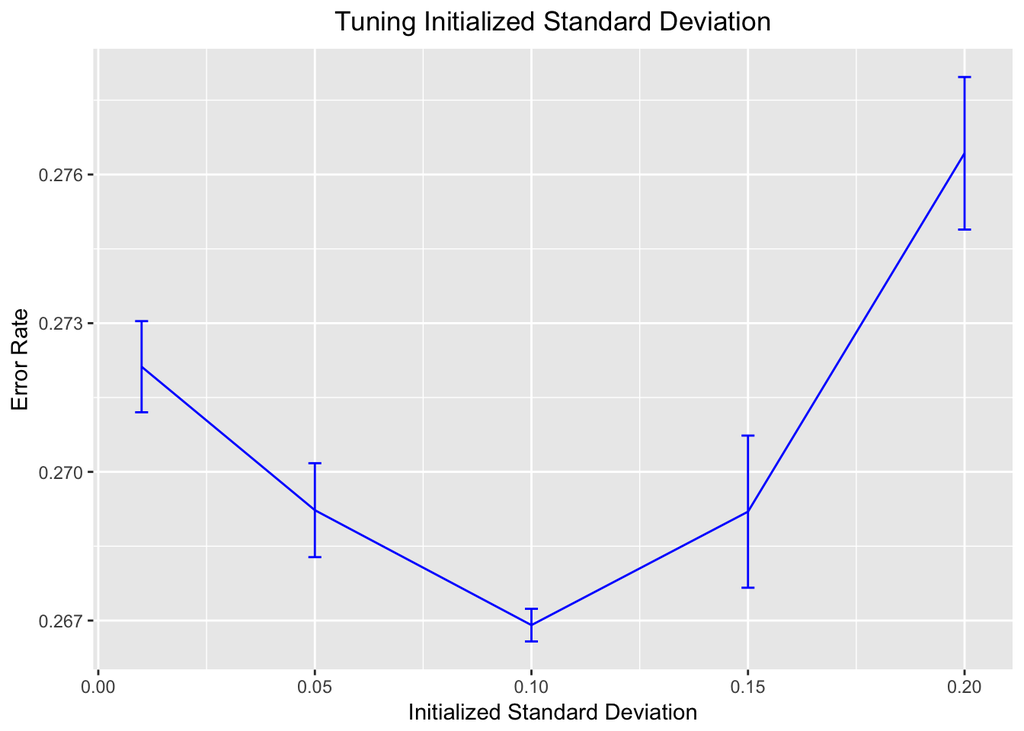

```r
cv_sd_results[[2]] + xlab("Initialized Standard Deviation") +
  ggtitle('Tuning Initialized Standard Deviation')
```

The optimal standard deviation is clearly .1.

### FM Model

From the parameter tuning above, we determine that k = 25 latent dimensions gives us the highest accuracy. Additionally, an initialized standard deviation of 0.1 leads to the quickest error rate convergence. Thus, we will set the hyperparamters to these values for our final model. We will train our final factorization machine model using 500 iterations of MCMC to ensure convergence in error rate. We then use this model to generate predictions for the testing dataset.

```r
#create an FM model with chosen  hyperparameters (k = 25 and init_stdev = .1)
predFM.mcmc <- libFM(merged_training, merged_testing, target ~ song_id + language + artist_name +
                        one + no_of_genre + msno + city + gender + logbd + log_song_length +
                        source_system_tab + source_screen_name + source_type,
                      task = "c", dim = k, init_stdev = .1, iter = 500,
                      verbosity = 1, method = "mcmc")

#predFM.mcmc.accuracy contains the console output of libFM
#(that is, the training and testing accuracy for each iteration of MCMC)
predFM.mcmc.err <- 1 - predFM.mcmc.accuracy
predFM.mcmc.err <- cbind(Iteration = 1:500, predFM.mcmc.err)
names(predFM.mcmc.err)[2:3] <- c('Train', 'Test')
```

We look at the training and testing error as a function of the number of iterations of MCMC to ensure the error rate converges in 500 iterations.

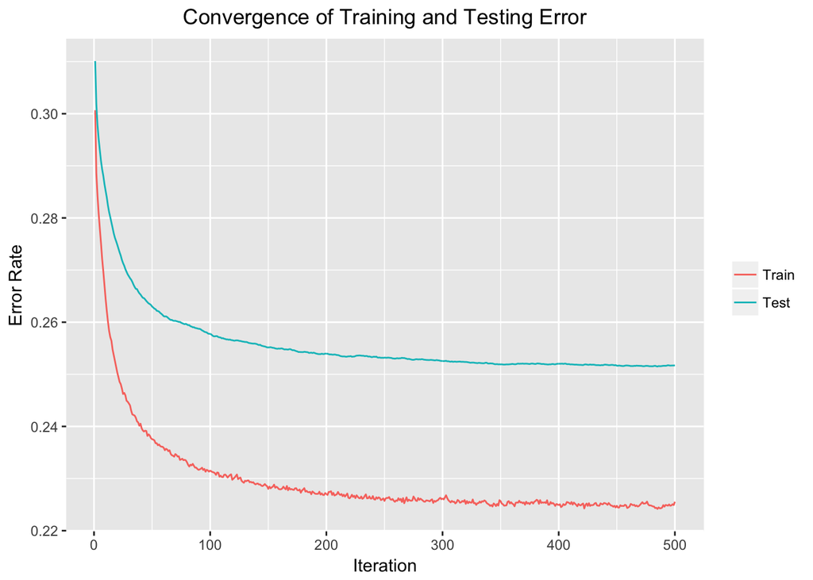

```r
err.conv <- predFM.mcmc.err %>% melt(id = 1) %>%
  ggplot(aes(x = Iteration, y = value, color = variable)) +
  geom_line() + ylab('Error Rate') +
  ggtitle('Convergence of Training and Testing Error') +
  theme(legend.title=element_blank(), plot.title = element_text(hjust = 0.5))
err.conv
```

The decrease in error rate is very small after approximately 300 iterations, for we conclude that 500 iterations is sufficient to train the model.

### Evaluation

Finally, we evaluate the model according to the following metrics:

- accuracy
- error
- precision
- recall
- F1
- auc

Additionally, we display an ROC curve for the predictions.

We start by writing a generic evaluation function, which we will use to compare the performance of different models:

```r
evaluate <- function(scores, target){
  ## Evaluate Predictions
  ## input
  # scores: vector of scores
  # (i.e. probability that an observation should have target value 1)
  # target: vector of actual target values
  ## returns
  # dataframe of evaluation metrics
  # confusion matrix for predicted and actual target values
  # roc object for plotting

  pred.target <- ifelse(scores >= 0.5, 1, 0)
  accuracy <- sum(pred.target == target)/length(target)
  error <- 1 - accuracy

  conf.mat <- table(pred.target, target, dnn = c("predicted","actual"))
  precision <- conf.mat[2,2]/sum(conf.mat[2,])
  recall <- conf.mat[2,2]/sum(conf.mat[,2])
  F1 <- 2 * (precision*recall/(precision + recall))
  auc <- auc(target, scores)
  eval.metrics <- data.frame(cbind(accuracy, error, precision, recall, F1, auc))

  roc <- roc(target, scores, direction="<")

  return(list(eval.metrics, conf.mat, roc))
}
```

We then call this function on the output probabilities of the FM model:

```r
FM.eval <- evaluate(scores = predFM.mcmc, target = testing_data$target)
FM.roc.plot <- ggroc(FM.eval[[3]], alpha = 0.5, colour = "blue", linetype = 2, size = 2) +
  theme(plot.title = element_text(hjust = 0.5))
```

Finally, we display the evaluation metrics and the ROC plot.

```r
FM.eval[[1]] #print evaluation metrics
```

| accuracy | error | precision | recall | F1 | auc |
| --- | --- | --- | --- | --- | --- |
| 0.7482754 | 0.2517246 | 0.7776237 | 0.8433959 | 0.8091754 | 0.8145012 |

```r
FM.eval[[2]] #print confusion matrix
```

```
##          actual
## predicted      0      1
##         0  62209  28732
##         1  44250 154737
```

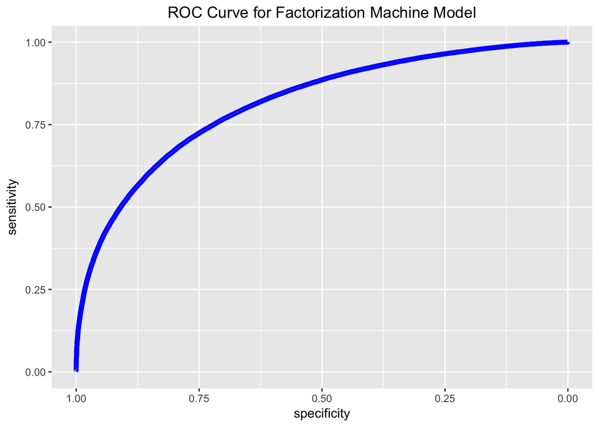

```r
FM.roc.plot + ggtitle('ROC Curve for Factorization Machine Model') +
  theme(plot.title = element_text(hjust = 0.5))
```

## Content Based Recommender

In this section, we build the content based recommendation from scratch without using any ready to build package.

- Content-based systems are designed to exploit scenarios in which items can be described with descriptive sets of attributes.
- This approach is particularly useful when the item is new, and there are few ratings available for that item.
- Unlike collaborative systems, which explicitly leverage the ratings of other users in addition to that of the target user, content-based systems largely focus on the target user’s own ratings and the attributes of the items liked by the user. Therefore, the other users have little, if any, role to play in content-based systems.
- Content-based systems are largely used in scenarios in which a significant amount of attribute information is available at hand. In this case, we have structured data in the form of song length, genres, artists, composer, lyricist and language.
- The general architecture of a content based recommender can be visualized through the following diagram.

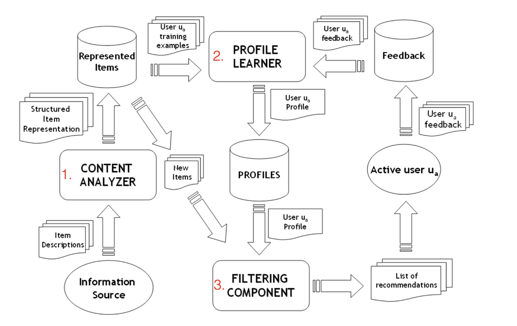

We do the following step to build our content based recommender by utilising these song features.

### Preprocessing and Feature Extraction

```r
genres <- as.data.frame(songs$genre_ids, stringsAsFactors=FALSE)
genres <- as.data.frame(tstrsplit(genres[,1], '[|]', type.convert=TRUE), stringsAsFactors=FALSE)
colnames(genres) <- c(1:3)
genres$song_id <- songs$song_id

genre_data <- genres[c(4,1)]
for(i in 2:3){
  tester <- genres[c(4,i)]
  tester <- na.omit(tester)
  names(tester) <- names(genre_data)
  genre_data <- rbind(genre_data, tester)
}
names(genre_data) <- c('song_id', 'genre')
genre_binary <- dcast(genre_data, formula = song_id~genre, fun.aggregate = NULL)
genre_binary[-1][!is.na(genre_binary[-1])] <- 1
genre_binary[is.na(genre_binary)] <- 0

lang_data <- songs[c('song_id', 'language')]
lang_data <- na.omit(lang_data)
lang_binary <- dcast(lang_data, formula = song_id~language, fun.aggregate = NULL)
lang_binary[-1][!is.na(lang_binary[-1])] <- 1
lang_binary[is.na(lang_binary)] <- 0

artists <- as.data.frame(songs$artist_name, stringsAsFactors=FALSE)
artists <- as.data.frame(tstrsplit(artists[,1], '[|]', type.convert=TRUE), stringsAsFactors=FALSE)
colnames(artists) <- c(1:3)
artists$song_id <- songs$song_id

artists_data <- artists[c(4,1)]
for(i in 2:3){
  tester <- artists[c(4,i)]
  tester <- na.omit(tester)
  names(tester) <- names(artists_data)
  artists_data <- rbind(artists_data, tester)
}
names(artists_data) <- c('song_id', 'artist')
artists_binary <- dcast(artists_data, formula = song_id~artist, fun.aggregate = NULL)
artists_binary[-1][!is.na(artists_binary[-1])] <- 1
artists_binary[is.na(artists_binary)] <- 0

composer <- as.data.frame(songs$composer, stringsAsFactors=FALSE)
composer <- as.data.frame(tstrsplit(composer[,1], '[|]', type.convert=TRUE), stringsAsFactors=FALSE)
colnames(composer) <- c(1:11)
composer$song_id <- songs$song_id

composer_data <- composer[c(12,1)]
for(i in 2:11){
  tester <- composer[c(12,i)]
  tester <- na.omit(tester)
  names(tester) <- names(composer_data)
  composer_data <- rbind(composer_data, tester)
}
names(composer_data) <- c('song_id', 'composers')
composer_binary <- dcast(composer_data, formula = song_id~composers, fun.aggregate = NULL)
composer_binary[-1][!is.na(composer_binary[-1])] <- 1
composer_binary[is.na(composer_binary)] <- 0

lyricist <- as.data.frame(songs$lyricist, stringsAsFactors=FALSE)
lyricist <- as.data.frame(tstrsplit(lyricist[,1], '[|]', type.convert=TRUE), stringsAsFactors=FALSE)
colnames(lyricist) <- c(1:11)
lyricist$song_id <- songs$song_id

lyricist_data <- lyricist[c(12,1)]
for(i in 2:11){
  tester <- lyricist[c(12,i)]
  tester <- na.omit(tester)
  names(tester) <- names(lyricist_data)
  lyricist_data <- rbind(lyricist_data, tester)
}
names(lyricist_data) <- c('song_id', 'lyricists')
lyricist_binary <- dcast(lyricist_data, formula = song_id~lyricists, fun.aggregate = NULL)
lyricist_binary[-1][!is.na(lyricist_binary[-1])] <- 1
lyricist_binary[is.na(lyricist_binary)] <- 0


songs$song_length_bucket <- cut2(songs$song_length, cuts = quantile(songs$song_length, probs = c(0,0.25,0.75)))
length_data <- songs[c('song_id', 'song_length_bucket')]
length_data <- na.omit(length_data)
length_binary <- dcast(length_data, formula = song_id~song_length_bucket, fun.aggregate = NULL)
length_binary[-1][!is.na(length_binary[-1])] <- 1
length_binary[is.na(length_binary)] <- 0
names(length_binary) <- c('song_id','low', 'med', 'high')

big_flat_item_features <- as.data.frame(cbind(length_binary,
                                              genre_binary[2:ncol(genre_binary)],
                                              artists_binary[2:ncol(artists_binary)],
                                              composer_binary[2:ncol(composer_binary)],
                                              lyricist_binary[2:ncol(lyricist_binary)],
                                              lang_binary[2:ncol(lang_binary)]))
big_flat_item_features[2:ncol(big_flat_item_features)] <- sapply(big_flat_item_features[2:ncol(big_flat_item_features)], as.numeric)
```

```r
big_flat_item_features <- readRDS('content_based/big_flat_item_features.rds')
big_flat_item_features[1:3,1:20]
```

| song_id | low | med | high | 109 | 125 | 139 | 359 | 437 | 444 | 451 | 458 | 465 | 691 | 921 | 1011 | 1259 | 1609 | 1616 | 2022 |
| --- | --- | --- | --- | --- | --- | --- | --- | --- | --- | --- | --- | --- | --- | --- | --- | --- | --- | --- | --- |
| 1 | 0 | 1 | 0 | 0 | 0 | 0 | 0 | 0 | 0 | 0 | 0 | 0 | 0 | 0 | 0 | 1 | 0 | 0 | 0 |
| 10 | 0 | 1 | 0 | 0 | 0 | 0 | 0 | 0 | 0 | 0 | 0 | 1 | 0 | 0 | 0 | 1 | 0 | 0 | 0 |
| 100 | 0 | 1 | 0 | 0 | 0 | 0 | 0 | 0 | 0 | 0 | 1 | 0 | 0 | 0 | 0 | 0 | 0 | 0 | 0 |

We now have our items represented as feature vectors

### knn Classification Model

- The nearest neighbor classifier is one of the simplest classification techniques, and it can be implemented in a relatively straightforward way.
- We construct model for each user based on his/her ratings for the items. Content based recommender system can be thought of as a classification problem for each user.

```r
total_prediction_matrix <- data.frame()
near_neighbors = 2^c(2:5)
for(active_user in user_key$msno){
  items_rated <- training_data$song_id[training_data$msno == active_user]
  train <- subset(big_flat_item_features, big_flat_item_features$song_id %in% items_rated)
  user_target <- subset(training_data[1:3], training_data$msno == active_user)
  user_target$target <- as.factor(user_target$target)
  train$target <- user_target$target[match(train$song_id, user_target$song_id)]
  train <- train[-1]
  train_knn <- train[1:2035]
  #test_knn <- train[1:2035]
  cl <- train$target

  items_not_rated <- testing_data$song_id[testing_data$msno == active_user]
  test <- subset(big_flat_item_features, big_flat_item_features$song_id %in% items_not_rated)

  user_test_target <- subset(testing_data, testing_data$msno == active_user)
  test$target <- testing_data$target[match(test$song_id, testing_data$song_id)]
  test_knn = test[2:2036]
  for(nn in near_neighbors){
    preds <- knn(train_knn, test_knn, cl, k = nn, prob=TRUE)
    prediction_matrix <- as.data.frame(cbind(active_user, test$song_id, test$target, attributes(preds)$prob, as.numeric(as.character(preds)), nn))
    names(prediction_matrix) <- c('active_user', 'song_id', 'target', 'prediction_prob', 'prediction', 'nn')
    total_prediction_matrix <- rbind(total_prediction_matrix, prediction_matrix)

  }
  print(paste(active_user, "complete"))
}
```

### Evaluation

- We compare the content based model with the collaborative filter models and see that it is better than random prediction and outperforms user-based collaborative filtering, however, the number of neighbors in the knn model were restricted to 32, thus under performing item-based collaborative filter.

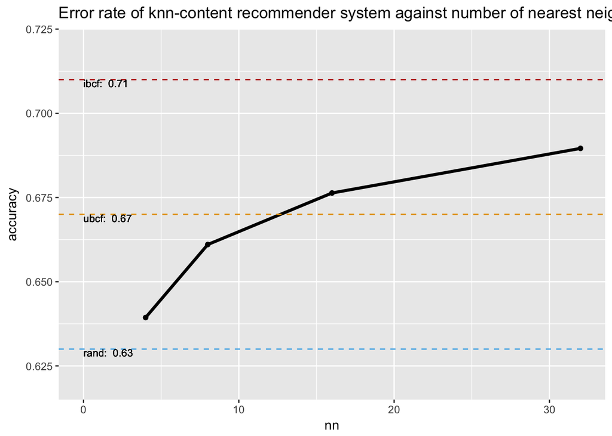

```r
h <- round(ibcf_accuracy,2)
i <- round(ubcf_accuracy,2)
j <- round(rand_accuracy,2)
nn_plot <- ggplot(data=accuracy_nn, aes(x=nn, y=accuracy, group=1)) +
  geom_line(size=1.2)+
  ggtitle('Error rate of knn-content recommender system against number of nearest neighbors. [CF for benchmarking]') +
  geom_hline(aes(yintercept=h), colour="#BB0000", linetype="dashed") +
  geom_text(aes(0, h, label = paste("ibcf: ",h), vjust = 1, hjust = 0), size = 3) +
  geom_hline(aes(yintercept=i), colour="#E69F00", linetype="dashed") +
  geom_text(aes(0, i, label = paste("ubcf: ",i), vjust = 1, hjust = 0), size = 3) +
  geom_hline(aes(yintercept=j), colour="#56B4E9", linetype="dashed") +
  geom_text(aes(0, j, label = paste("rand: ",j), vjust = 1, hjust = 0), size = 3) +
  geom_point(size = 1.5) +
  ylim(0.62, 0.72)

nn_plot
```

## References